# Systemy Decyzyjne 2023/2024

Laboratorium 4 - podstawowe modele predykcyjne

Andrzej Janusz

## Naive Bayes

Jednym z przykładów prostego model predykcyjnego jest *Naive Bayes*.

Twierdzenie Bayesa (w najprostszej postaci):
$$P(Y|X) = P(Y)*P(X|Y) / P(X)$$
U nas $X$ to wielowymiarowa zmienna losowa. Pojedynczy obiekt w danych traktujemy jak jej realizację, czyli pojedynczy obiekt to wektor konkretnych wartości $<x_1, ..., x_N>$. Załóżmy, że każda z wartości $x_1, \ldots, x_N$ ma niezerowe prawdopodobieństwo wystąpienia (czyli w uproszczeniu atrybuty mają wartości symboliczne i każda z tych wartości jest możliwa). $Y$ to u nas decyzja (także zmienna losowa).

Przepisujemy twierdzenia Bayesa:
$$P(Y =
y|X = <x_1, \ldots, x_N>) = \frac{P(Y = y)*P(X = <x_1, \ldots,
x_N>|Y = y)}{P(X = <x_1, \ldots, x_N>)}$$
Teraz “naiwnie” zakladamy, że $<x_1, \ldots, x_N>$ odpowiada realizacji $N$ niezależnych zmiennych losowych $X_1, \ldots, X_N$. Dostajemy:
$$P(Y = y|X = <x_1, \ldots, x_N>) = \frac{P(Y
= y)*P(X_1 = x_1|Y = y)* \ldots *P(X_N = x_N|Y = y)}{P(X1 = x_1)* \ldots
*P(X_N = x_N)}$$
Klasyfikator *Naive Bayes* przypisuje testowanemu obiektowi klasę o najwyższym prawdopodobieństwie a posteriori, czyli tą, dla której iloczyn z licznika powyższego ułamka jest największy. W przypadku, gdy atrybuty przyjmują wartości rzeczywisce (prawdopodobieństwo uzyskania konkretnej wartości jest bliskie 0), wykorzystuje się wartości gęstosci danego rozkładu lub dyskretyzuje dane.

```r
# wczytajmy zabawkowe dane:
dataPath = 'https://raw.githubusercontent.com/pritomzap/CSV-to-ARFF-converter/master/weather_nominal.csv'
data_golf = fread(dataPath, header = TRUE, sep = ',', stringsAsFactors = TRUE)
data_golf
```

| Outlook | Temperature | Humidity | Windy | Play golf |
| --- | --- | --- | --- | --- |
| Rainy | Hot | High | FALSE | No |
| Rainy | Hot | High | TRUE | No |
| Overcast | Hot | High | FALSE | Yes |
| Sunny | Mild | High | FALSE | Yes |
| Sunny | Cool | Normal | FALSE | Yes |
| Sunny | Cool | Normal | TRUE | No |
| Overcast | Cool | Normal | TRUE | Yes |
| Rainy | Mild | High | FALSE | No |
| Rainy | Cool | Normal | FALSE | Yes |
| Sunny | Mild | Normal | FALSE | Yes |

[output cut: 4 more lines]

```r
# naprawmy nazwę ostatniej kolumny
setnames(data_golf, "Play golf", "Play.golf")

# zapisuję wartości decyzji na osobny wektor
clsVec = data_golf[, Play.golf]

# żeby lepiej kontrolować eksperyment zainicjujmy generator liczb pseudolosowych
set.seed(123)

# wyznaczmy przykładowy podzbiór treningowy:
trainingIdx = sample(nrow(data_golf), 7)

# definiujemy nowe zadanie predykcji
golf_task <- TaskClassif$new(id = "golf_dt", backend = data_golf,
                             target = "Play.golf")

# wizualizacja danych
ggplot(data_golf, aes(x = Play.golf)) + geom_bar(aes(fill = Play.golf))
```

[figure not shown]

```r
# stwórzmy model Naive Bayes
nb_learner <- lrn("classif.naive_bayes")
# możemy sprawdzić aktualne ustawienia parametrów modelu
nb_learner$param_set
```

```
## <ParamSet>
##           id    class lower upper nlevels default value
## 1:       eps ParamDbl  -Inf   Inf     Inf       0
## 2:   laplace ParamDbl     0   Inf     Inf       0
## 3: threshold ParamDbl  -Inf   Inf     Inf   0.001
```

```r
nb_learner$param_set$values <- list(laplace = 100)

# manual dla modelu:
?e1071::naiveBayes
```

```
## uruchamianie serwera httpd dla pomocy ... wykonano
```

```r
# przetestujmy model
nb_learner$train(golf_task, row_ids = trainingIdx)
prediction <- nb_learner$predict(golf_task,
                                 row_ids = setdiff(1:nrow(data_golf), trainingIdx))

# macierz pomyłek i dokładność predykcji:
prediction$confusion
```

```
##         truth
## response No Yes
##      No   0   0
##      Yes  2   5
```

```r
acc <- msr("classif.acc")
prediction$score(acc)
```

```
## classif.acc
##   0.7142857
```

```r
# model
nb_learner$model
```

```
##
## Naive Bayes Classifier for Discrete Predictors
##
## Call:
## naiveBayes.default(x = x, y = y, laplace = 100)
##
## A-priori probabilities:
## y
##        No       Yes
## 0.4285714 0.5714286
##
## Conditional probabilities:
##      Humidity
## y          High    Normal
##   No  0.5024631 0.4975369
##   Yes 0.5000000 0.5000000
##
##      Outlook
## y      Overcast     Rainy     Sunny
##   No  0.3300330 0.3333333 0.3366337
##   Yes 0.3322368 0.3289474 0.3388158
##
##      Temperature
## y          Cool       Hot      Mild
##   No  0.3333333 0.3333333 0.3333333
##   Yes 0.3322368 0.3322368 0.3355263
##
##      Windy
## y         FALSE      TRUE
##   No  0.4926108 0.5073892
##   Yes 0.5098039 0.4901961
```

## Regresja logistyczna

Innym popularnym modelem predykcyjnym jest regresja logistyczna. W klasycznym podejściu jest to model statystyczny slużący przewidywaniu *binarnej decyzji*. Operuje się w nim pojęciem “szansy” wyrażajacej stosunek prawdopodobieństwa klasy “1” do prawdopodobieństwa klasy “0”.
$$Odds = \frac{p}{1-p} =
e^{\alpha}e^{\beta X}$$
Logarytm “szansy” wyraża się jako funkcję liniową wartości atrybutów warunkowych. Jest to funkcja *logit*. Parametry modelu $\alpha, \beta$ optymalizuje sie wykorzystując dane treningowe, np. metodą *najmniejszych kwadratów*, *największej wiarygodności* lub metodą *schodzenia po gradiencie*.

```r
# Wczytujemy dane:
data_wdbc <- data.table::fread(file = file.path(getwd(), "wdbc.data"), header = FALSE,
                               sep=',', na.strings="?", stringsAsFactors = TRUE, drop = 1)
setnames(data_wdbc, c("diagnosis",
                      paste(c(rep("mean",10), rep("SE",10), rep("worst",10)),
                            rep(c("radius", "texture", "perimeter", "area",
                                  "smoothness", "compactness", "concavity",
                                  "concave_points", "symmetry", "fractal_dimension"),3),
                            sep="_")))

# tak jak wczesniej, podzielmy dane na dwa zbiory:
set.seed(123)
trainingIdx = sample(nrow(data_wdbc), round(3*(nrow(data_wdbc)/5)))

# definiujemy nowe zadanie predykcji
wdbc_task <- TaskClassif$new(id = "wdbc_dt", backend = data_wdbc,
                             target = "diagnosis")
```

```r
# ponownie definiujemy model
glm_learner <- lrn("classif.cv_glmnet")

# trenujemy model
glm_learner$train(wdbc_task, row_ids = trainingIdx)

# predykcjia dla nowych danych
prediction <- glm_learner$predict(wdbc_task, row_ids = setdiff(1:nrow(data_wdbc), trainingIdx))
# macierz pomyłek i dokładność predykcji:
prediction$confusion
```

```
##         truth
## response   B   M
##        B 131   6
##        M   1  90
```

```r
acc <- msr("classif.acc")
prediction$score(acc)
```

```
## classif.acc
##   0.9692982
```

```r
# model
coef(glm_learner$model)
```

```
## 31 x 1 sparse Matrix of class "dgCMatrix"
##                                   s1
## (Intercept)              17.34994617
## SE_area                  -0.01865897
## SE_compactness            .
## SE_concave_points         .
## SE_concavity              .
## SE_fractal_dimension      .
## SE_perimeter              .
## SE_radius                -0.28858921
## SE_smoothness             .
## SE_symmetry               .
## SE_texture                .
## mean_area                 .
## mean_compactness          .
## mean_concave_points      -6.08192104
## mean_concavity            .
## mean_fractal_dimension    .
## mean_perimeter            .
## mean_radius               .
## mean_smoothness           .
## mean_symmetry             .
## mean_texture             -0.07246070
## worst_area                .
## worst_compactness         .
## worst_concave_points    -20.51408792
## worst_concavity          -0.18366674
## worst_fractal_dimension   .
## worst_perimeter           .
## worst_radius             -0.44062266
## worst_smoothness         -7.51702546
## worst_symmetry           -3.67189688
## worst_texture            -0.09469835
```

```r
model_coefficients <- coef(glm_learner$model)[colnames(data_wdbc)[-1], ]

# mozemy go zwizualizowac w pierwszych dwoch PC
pca <- prcomp(data_wdbc[, -1, with = FALSE], center = TRUE, scale = TRUE)

lineIn2PCs = (cbind(rep(1, 30), pca$rotation) %*% c(coef(glm_learner$model)[1], model_coefficients))[1:3]
plot(pca$x[, 1:2], col=data_wdbc[, as.integer(diagnosis)] + 1,
     pch=data_wdbc[, as.character(diagnosis)], cex=0.7,
     main="WDBC data in 2 principal components")
abline(coef = c(lineIn2PCs[1]/lineIn2PCs[3], lineIn2PCs[2]/lineIn2PCs[3]),
       col = 'blue', lwd = 2)
```

[figure not shown]

## Drzewa decyzyjne

Jednym z najbardziej powszechnie stosowanym modelem predykcyjnym jest **drzewo decyzyjne**. Przykłady algorytmów konstruowania drzew decyzyjnych to *ID3*, *CART* oraz *C5.0* (i nowsze wersje). Najczęściej konstruowanie drzewa decyzyjnego dzieli sie na dwie fazy. W pierwszej generuje się wstępne drzewo przez rekursywne wybieranie najlepszego podzialu danych (tzw. cięcia) na pojedynczym atrybucie. W drugiej fazie upraszcza się drzewo przez ‘*przycinanie*’ (ang. pruning) węzłów, które nie przyczyniają się znacząco do redukcji liczby popełnianych błędów. Najczęściej wykorzystywanymi miarami jakości cięcia na atrybucie są:

- information gain (bazuje na entropii) – wartość oczekiwana redukcji entropii decyzji po wykonaniu cięcia,
- gini gain – wartość oczekiwana redukcji prawdopodobieństwa popełnienia błędu przy losowaniu decyzji zgodnie z rozkladami z liści,
- discernibility gain – liczba par obiektów z różnych klas decyzyjnych, które rozróżni dane cięcie.

```r
tree_learner <- lrn("classif.rpart", cp = 0.01, minsplit = 5)

# trenowanie i ewaluacja
tree_learner$train(wdbc_task, row_ids = trainingIdx)
prediction <- tree_learner$predict(wdbc_task, row_ids = setdiff(1:nrow(data_wdbc), trainingIdx))
prediction$confusion
```

```
##         truth
## response   B   M
##        B 124   6
##        M   8  90
```

```r
acc <- msr("classif.acc")
CV <- rsmp("cv", folds = 10L)
rr <- resample(wdbc_task, tree_learner, CV)
```

[output not shown]

```r
rr$score(acc)
```

| task | task_id | learner | learner_id | resampling | resampling_id | iteration | prediction | classif.acc |
| --- | --- | --- | --- | --- | --- | --- | --- | --- |
|  | wdbc_dt |  | classif.rpart |  | cv | 1 |  | 0.9473684 |
|  | wdbc_dt |  | classif.rpart |  | cv | 2 |  | 0.9649123 |
|  | wdbc_dt |  | classif.rpart |  | cv | 3 |  | 0.8771930 |
|  | wdbc_dt |  | classif.rpart |  | cv | 4 |  | 0.8421053 |
|  | wdbc_dt |  | classif.rpart |  | cv | 5 |  | 0.8947368 |
|  | wdbc_dt |  | classif.rpart |  | cv | 6 |  | 0.8771930 |
|  | wdbc_dt |  | classif.rpart |  | cv | 7 |  | 0.8771930 |
|  | wdbc_dt |  | classif.rpart |  | cv | 8 |  | 0.9298246 |
|  | wdbc_dt |  | classif.rpart |  | cv | 9 |  | 0.9649123 |
|  | wdbc_dt |  | classif.rpart |  | cv | 10 |  | 0.9642857 |

```r
# model
tree_learner$model
```

```
## n= 341
##
## node), split, n, loss, yval, (yprob)
##       * denotes terminal node
##
##  1) root 341 116 B (0.659824047 0.340175953)
##    2) worst_perimeter< 114.45 248  25 B (0.899193548 0.100806452)
##      4) worst_concave_points< 0.1589 235  13 B (0.944680851 0.055319149)
##        8) mean_texture< 21.315 188   1 B (0.994680851 0.005319149) *
##        9) mean_texture>=21.315 47  12 B (0.744680851 0.255319149)
##         18) worst_perimeter< 101.05 35   3 B (0.914285714 0.085714286) *
##         19) worst_perimeter>=101.05 12   3 M (0.250000000 0.750000000)
##           38) SE_compactness>=0.042475 2   0 B (1.000000000 0.000000000) *
##           39) SE_compactness< 0.042475 10   1 M (0.100000000 0.900000000) *
##      5) worst_concave_points>=0.1589 13   1 M (0.076923077 0.923076923) *
##    3) worst_perimeter>=114.45 93   2 M (0.021505376 0.978494624) *
```

```r
rpart.plot(tree_learner$model, type = 2, digits = 2, tweak = 1.0, roundint=FALSE,
           main = 'drzewo decyzyjne')
```

[figure not shown]

## Zadanie

Proszę spróbować znaleźć optymalne wartości hiperparametrów omówionych dzisiaj modeli dla danych *wdbc*. Proszę spróbować wykorzystać w tym zadanu pakiet *mlr3tuning*.

```r
# to jest miejsce na rozwiazanie zadania:
tree_learner_optimised <- lrn("classif.rpart")
tree_learner_optimised$param_set
```

```
## <ParamSet>
##                 id    class lower upper nlevels        default value
##  1:             cp ParamDbl     0     1     Inf           0.01
##  2:     keep_model ParamLgl    NA    NA       2          FALSE
##  3:     maxcompete ParamInt     0   Inf     Inf              4
##  4:       maxdepth ParamInt     1    30      30             30
##  5:   maxsurrogate ParamInt     0   Inf     Inf              5
##  6:      minbucket ParamInt     1   Inf     Inf <NoDefault[3]>
##  7:       minsplit ParamInt     1   Inf     Inf             20
##  8: surrogatestyle ParamInt     0     1       2              0
##  9:   usesurrogate ParamInt     0     2       3              2
## 10:           xval ParamInt     0   Inf     Inf             10     0
```

```r
tree_learner_optimised$param_set$values <- list(cp = to_tune(0, 0.5), minsplit = to_tune(1, 100))
instance = ti(
  task = wdbc_task,
  learner = tree_learner_optimised,
  resampling = rsmp("cv", folds = 10L),
  measures = msr("classif.acc"),
  terminator = trm("none")
)
instance
```

```
## <TuningInstanceSingleCrit>
## * State:  Not optimized
## * Objective: <ObjectiveTuning:classif.rpart_on_wdbc_dt>
## * Search Space:
##          id    class lower upper nlevels
## 1:       cp ParamDbl     0   0.5     Inf
## 2: minsplit ParamInt     1 100.0     100
## * Terminator: <TerminatorNone>
```

```r
tuner = tnr("grid_search", resolution = 5)

tuner$optimize(instance)
```

[output not shown]

[output cut: 350 more lines]

[output not shown]

| cp | minsplit | learner_param_vals | x_domain | classif.acc |
| --- | --- | --- | --- | --- |
| 0 | 75 |  |  | 0.9262845 |

```r
tree_learner_optimised$param_set$values = instance$result_learner_param_vals
tree_learner_optimised$wdbc_data
```

```r
tree_learner_optimised$train(wdbc_task, row_ids = trainingIdx)
prediction <- tree_learner_optimised$predict(wdbc_task, row_ids = setdiff(1:nrow(data_wdbc), trainingIdx))
prediction$confusion
```

```
##         truth
## response   B   M
##        B 122   5
##        M  10  91
```

```r
acc <- msr("classif.acc")
prediction$score(acc)
```

```
## classif.acc
##   0.9342105
```

```r
# model
tree_learner_optimised$model
```

```
## n= 341
##
## node), split, n, loss, yval, (yprob)
##       * denotes terminal node
##
## 1) root 341 116 B (0.65982405 0.34017595)
##   2) worst_perimeter< 114.45 248  25 B (0.89919355 0.10080645)
##     4) worst_concave_points< 0.13595 218   8 B (0.96330275 0.03669725) *
##     5) worst_concave_points>=0.13595 30  13 M (0.43333333 0.56666667) *
##   3) worst_perimeter>=114.45 93   2 M (0.02150538 0.97849462) *
```

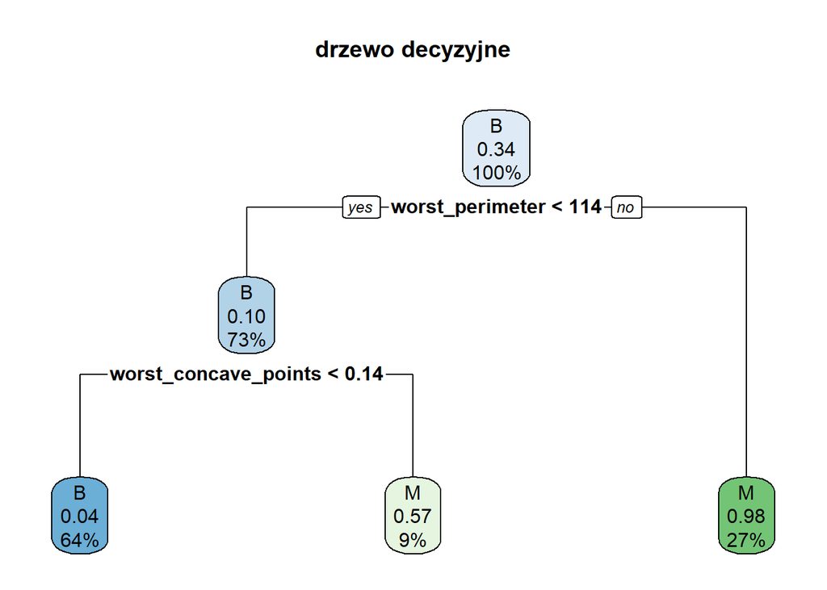

```r
rpart.plot(tree_learner_optimised$model, type = 2, digits = 2, tweak = 1.0, roundint=FALSE,
           main = 'drzewo decyzyjne')
```

```r
acc <- msr("classif.acc")
CV <- rsmp("cv", folds = 10L)
rr <- resample(wdbc_task, tree_learner_optimised, CV)
```

[output not shown]

```r
rr$score(acc)
```

| task | task_id | learner | learner_id | resampling | resampling_id | iteration | prediction | classif.acc |
| --- | --- | --- | --- | --- | --- | --- | --- | --- |
|  | wdbc_dt |  | classif.rpart |  | cv | 1 |  | 0.9122807 |
|  | wdbc_dt |  | classif.rpart |  | cv | 2 |  | 0.9122807 |
|  | wdbc_dt |  | classif.rpart |  | cv | 3 |  | 0.9298246 |
|  | wdbc_dt |  | classif.rpart |  | cv | 4 |  | 0.8771930 |
|  | wdbc_dt |  | classif.rpart |  | cv | 5 |  | 0.8596491 |
|  | wdbc_dt |  | classif.rpart |  | cv | 6 |  | 0.9298246 |
|  | wdbc_dt |  | classif.rpart |  | cv | 7 |  | 0.9122807 |
|  | wdbc_dt |  | classif.rpart |  | cv | 8 |  | 0.9122807 |
|  | wdbc_dt |  | classif.rpart |  | cv | 9 |  | 0.9649123 |
|  | wdbc_dt |  | classif.rpart |  | cv | 10 |  | 0.9464286 |

```r
instance$result_learner_param_vals
```

```
## $cp
## [1] 0
##
## $minsplit
## [1] 75
```

[output not shown]